# Project5 Data Visulaization: Ford GoBike Data

## Which docks are used more frequently?

### Top 20 station

```python
start_station = df['start_station_name'].unique()
```

```python
start_station_from_df = df[df['start_station_name'].isin(start_station)]
```

```python
start_station_lon_lat_df = start_station_from_df.groupby('start_station_name')[['start_station_longitude', 'start_station_latitude', 'duration_sec', 'distance_miles_estimates']].mean()
```

```python
top_20_start_staion = df.groupby(['start_station_name']).size().sort_values(ascending=False)[:20].to_frame().reset_index().start_station_name
```

```python
top_20_start_station_from_df = df[df.start_station_name.isin(top_20_start_staion)]
```

```python
top_20_start_station_lon_lat_df = top_20_start_station_from_df.groupby('start_station_name')[['start_station_longitude', 'start_station_latitude', 'duration_sec', 'distance_miles_estimates']].mean()
```

```python
output_notebook()

map_options = GMapOptions(lat=37.77, lng=-122.41, map_type="roadmap", zoom=13)

# For GMaps to function, Google requires you obtain and enable an API key:
#
#     https://developers.google.com/maps/documentation/javascript/get-api-key
#
# Replace the value below with your personal API key:5
p = gmap("AIzaSyAP5z93hiJppmyZoEoDj47ORBgk5yivRSM", map_options, plot_width=700, plot_height=700)
p.title.text = "Top 20 most popular docks among all docks"
p.title.text_font_size = "20px"
p.title.align = "center"

source1 = ColumnDataSource(
    data = dict(lat = start_station_lon_lat_df['start_station_latitude'].tolist(),
                lon = start_station_lon_lat_df['start_station_longitude'].tolist())
)

source2 = ColumnDataSource(
    data = dict(lat = top_20_start_station_lon_lat_df['start_station_latitude'].tolist(),
                lon = top_20_start_station_lon_lat_df['start_station_longitude'].tolist())
)


p.circle(x="lon", y="lat", size=9, color="blue", fill_alpha=0.5, legend="Ford bike docks", source=source1)
p.circle(x="lon", y="lat", size=9, color="red", fill_alpha=0.9, legend="top 20 most popular docks", source=source2)

p.legend.label_text_font_size = '12pt'
p.legend.location = "top_left"
show(p);
```

[interactive chart not shown]

This is to show where the ford goBike docks are distributed and top 20 docks are aorund market street and SOMA, where lots of companies are located.

## When and where 'Bike share for all' members use Ford goBike?

'Bike share for all' is a program which is offered by Ford goBike to sponsor low income people who meet certain criteria. Bike Share for All is available to Bay Area residents ages 18 and older who qualify for Calfresh, SFMTA (Low Income) Lifeline Passes or PG&E CARE utility discount. [For more information](https://www.fordgobike.com/pricing/bikeshareforall)

### Count of 'Bike share for all' rides per hour

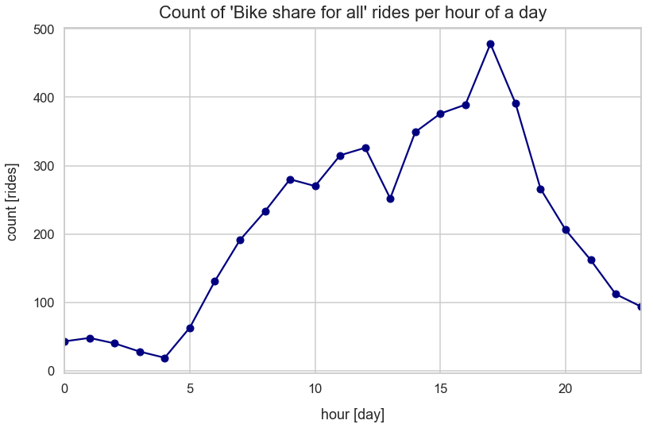

```python
df[df['bike_share_for_all_trip']=='Yes'].groupby('start_time_hour').agg({'bike_id':'count'}).plot(style='-o', figsize=(13,8), color='navy', legend=False)
plt.title("Count of 'Bike share for all' rides per hour of a day", fontsize=22, y=1.015)
plt.xlabel('hour [day]', labelpad=16)
plt.ylabel('count [rides]', labelpad=16)
plt.savefig('image08.png');
```

It seems that 5pm is peak hour for 'Bike share for all' rides. However, they use less when going to work than going home.